# Árboles de regresión: K regresores

# 1 Arbol con regresores cuantitativos y cualitativos

```r
library(rpart)
d = read.csv('datos/kidiq.csv')
d$mom_hs = factor(d$mom_hs, labels = c("no", "si"))
d$mom_work = factor(d$mom_work, labels = c("notrabaja", "trabaja23", "trabaja1_parcial", "trabaja1_completo"))
```

```r
# method = "anova" para modelos de regresion
t1 = rpart(kid_score ~ ., data = d, method = "anova")
```

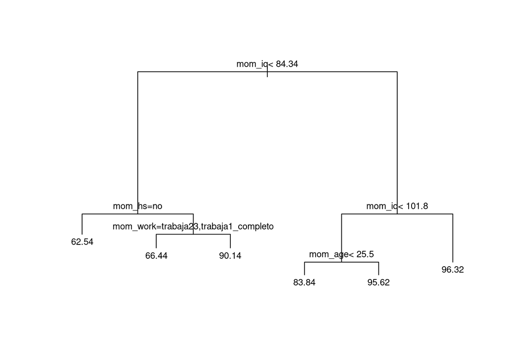

```r
plot(t1, margin = 0.02)
text(t1, cex = 0.75, pretty = 0)
```

```r
print(t1)
```

```
## n= 434
##
## node), split, n, deviance, yval
##       * denotes terminal node
##
##  1) root 434 180386.200 86.79724
##    2) mom_iq< 84.33641 69  29011.830 66.86957
##      4) mom_hs=no 35  11166.690 62.54286 *
##      5) mom_hs=si 34  16515.440 71.32353
##       10) mom_work=trabaja23,trabaja1_completo 27   9750.667 66.44444 *
##       11) mom_work=notrabaja,trabaja1_parcial 7   3642.857 90.14286 *
##    3) mom_iq>=84.33641 365 118793.700 90.56438
##      6) mom_iq< 101.8061 191  58829.520 85.31937
##       12) mom_age< 25.5 167  51906.630 83.83832 *
##       13) mom_age>=25.5 24   4007.625 95.62500 *
##      7) mom_iq>=101.8061 174  48941.980 96.32184 *
```

Como vemos, cuando hay una variables cualitativa, se van asignando los diferentes niveles del factor a cada rama que sale del nodo hasta que se encuentra la asignación con menor RSS: - En el nodo 2, si mom_hs = no, nos vamos hacia la izquierda; si mom_hs = si, nos vamos a la derecha. - En el nodo 5, si mom_work = trabaja23,trabaja1_completo nos vamos a la izquierda; si mom_work=notrabaja,trabaja1_parcial nos vamos a la derecha.

# 2 Parámetros del árbol

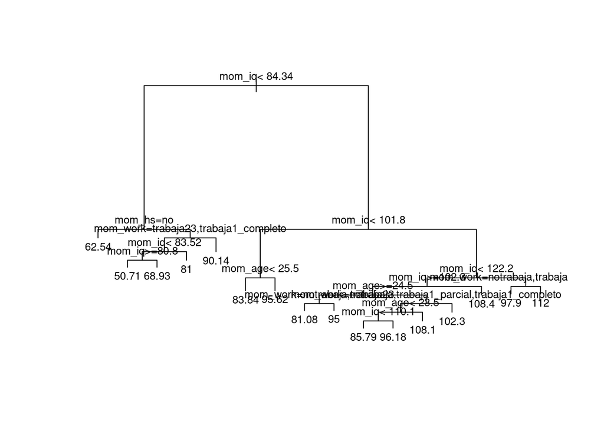

```r
t2 = rpart(kid_score ~ ., data = d, method = "anova",
    control = rpart.control(minsplit = 10, minbucket = 5, cp = 0.007))
plot(t2, margin = 0.02)
text(t2, cex=.75, pretty = 0)
```

```r
print(t2)
```

```
## n= 434
##
## node), split, n, deviance, yval
##       * denotes terminal node
##
##   1) root 434 180386.2000  86.79724
##     2) mom_iq< 84.33641 69  29011.8300  66.86957
##       4) mom_hs=no 35  11166.6900  62.54286 *
##       5) mom_hs=si 34  16515.4400  71.32353
##        10) mom_work=trabaja23,trabaja1_completo 27   9750.6670  66.44444
##          20) mom_iq< 83.51527 22   8034.5910  63.13636
##            40) mom_iq>=80.79538 7    545.4286  50.71429 *
##            41) mom_iq< 80.79538 15   5904.9330  68.93333 *
##          21) mom_iq>=83.51527 5    416.0000  81.00000 *
##        11) mom_work=notrabaja,trabaja1_parcial 7   3642.8570  90.14286 *
##     3) mom_iq>=84.33641 365 118793.7000  90.56438
##       6) mom_iq< 101.8061 191  58829.5200  85.31937
##        12) mom_age< 25.5 167  51906.6300  83.83832 *
##        13) mom_age>=25.5 24   4007.6250  95.62500 *
##       7) mom_iq>=101.8061 174  48941.9800  96.32184
##        14) mom_iq< 122.2355 132  38970.8100  94.53788
##          28) mom_iq>=102.2658 127  36978.9900  93.99213
##            56) mom_age>=24.5 37  11611.2400  90.48649
##             112) mom_work=notrabaja,trabaja23 12   6398.9170  81.08333 *
##             113) mom_work=trabaja1_parcial,trabaja1_completo 25   3642.0000  95.00000 *
##            57) mom_age< 24.5 90  24726.1000  95.43333
##             114) mom_work=notrabaja,trabaja1_parcial,trabaja1_completo 69  19845.6500  93.34783
##               228) mom_age< 23.5 61  17308.7500  91.40984
##                 456) mom_iq< 110.0551 28   7852.7140  85.78571 *
##                 457) mom_iq>=110.0551 33   7818.9090  96.18182 *
##               229) mom_age>=23.5 8    560.8750 108.12500 *
##             115) mom_work=trabaja23 21   3594.2860 102.28570 *
##          29) mom_iq< 102.2658 5    993.2000 108.40000 *
##        15) mom_iq>=122.2355 42   8230.7860 101.92860
##          30) mom_work=notrabaja,trabaja1_completo 30   5234.7000  97.90000 *
##          31) mom_work=trabaja23,trabaja1_parcial 12   1292.0000 112.00000 *
```

- Como vemos, en este caso el criterio que detiene el crecimiento del árbol es cp. Por ejemplo, el nodo 3 se ha dividido ya que

```r
(118793.70 - 58829.52 - 48941.98)/180386.20
```

```
## [1] 0.06110334
```

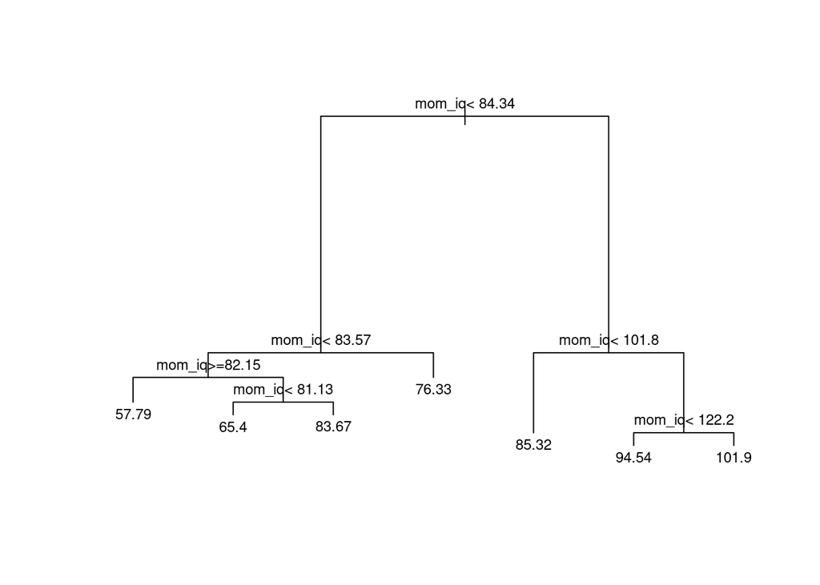

```r
t3 = rpart(kid_score ~ mom_iq, data = d, method = "anova",
    control = rpart.control(minsplit = 10, minbucket = 5, cp = 0.0069))
plot(t3, margin = 0.02)
text(t3, cex=.75)
```

```r
print(t3)
```

```
## n= 434
##
## node), split, n, deviance, yval
##       * denotes terminal node
##
##  1) root 434 180386.200  86.79724
##    2) mom_iq< 84.33641 69  29011.830  66.86957
##      4) mom_iq< 83.57478 60  26044.850  65.45000
##        8) mom_iq>=82.1513 14   5136.357  57.78571 *
##        9) mom_iq< 82.1513 46  19835.830  67.78261
##         18) mom_iq< 81.13004 40  14465.600  65.40000 *
##         19) mom_iq>=81.13004 6   3629.333  83.66667 *
##      5) mom_iq>=83.57478 9   2040.000  76.33333 *
##    3) mom_iq>=84.33641 365 118793.700  90.56438
##      6) mom_iq< 101.8061 191  58829.520  85.31937 *
##      7) mom_iq>=101.8061 174  48941.980  96.32184
##       14) mom_iq< 122.2355 132  38970.810  94.53788 *
##       15) mom_iq>=122.2355 42   8230.786 101.92860 *
```

```r
(48941.980 - 38970.810 - 8230.786)/180386.200
```

```
## [1] 0.009648099
```

- De nuevo cp es el parámetro más restrictivo.

# 3 Residuos

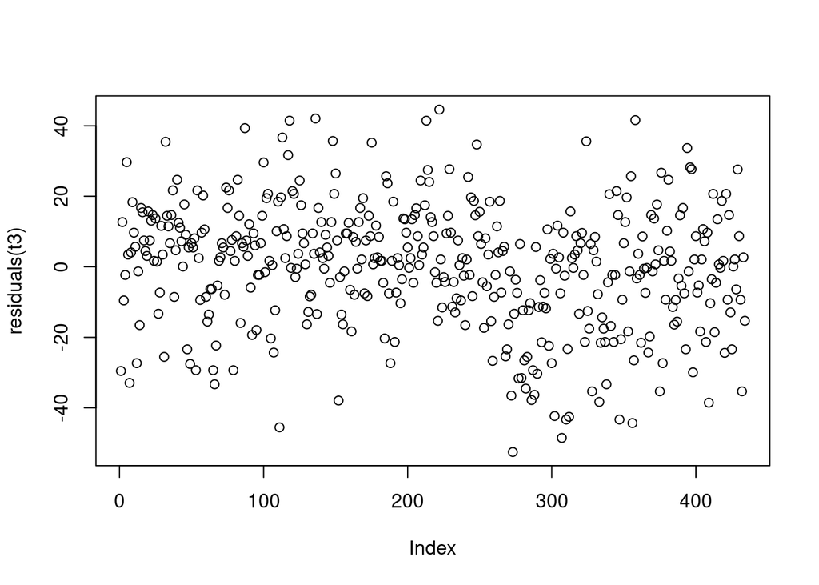

```r
plot(residuals(t3))
```

- El R2 se define a manera análoga a regresión

$$R^2 = 1 - \frac{RSS}{TSS}$$

- donde hay que recordar de RSS = deviance(nodo) y TSS = deviance(root)
- Se denomina error relativo al cociente RSS/TSS. Y la X indica que se ha calculado mediante validación cruzada.

```r
par(mfrow = c(1,2))
rsq.rpart(t3)
```

```
##
## Regression tree:
## rpart(formula = kid_score ~ mom_iq, data = d, method = "anova",
##     control = rpart.control(minsplit = 10, minbucket = 5, cp = 0.0069))
##
## Variables actually used in tree construction:
## [1] mom_iq
##
## Root node error: 180386/434 = 415.64
##
## n= 434
##
##          CP nsplit rel error  xerror     xstd
## 1 0.1806158      0   1.00000 1.00600 0.065309
## 2 0.0611036      1   0.81938 0.84495 0.058532
## 3 0.0096481      2   0.75828 0.79903 0.056661
## 4 0.0069121      3   0.74863 0.81797 0.058274
## 5 0.0069000      6   0.72790 0.85400 0.060370
```

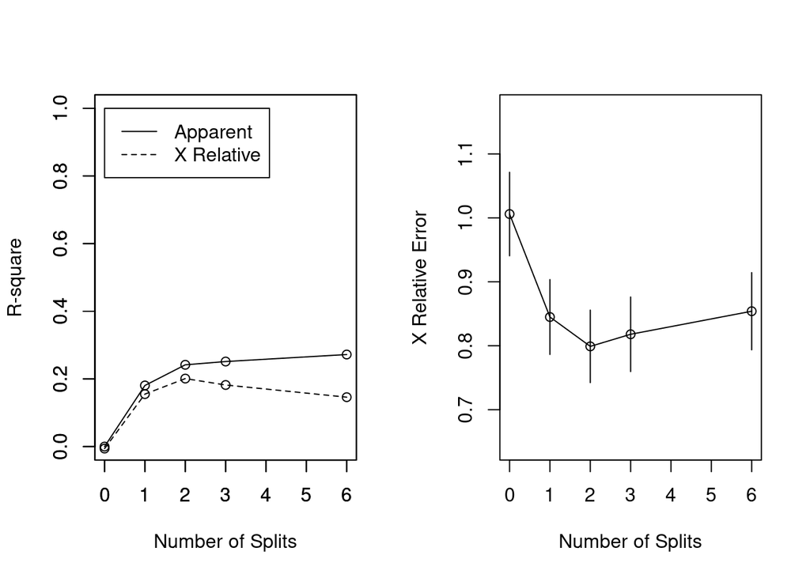

- Appatent: R2 calculado con la formula (1 - RSS/TSS)
- X Relative: R2 calculado con validación cruzada (como vemos, el R2 cuadrado con validación cruzada es menor que el apparent ya que uno esta calculado en los datos train y otro en los datos test).
- X relative error: 1 - X Relative, es decir, RSS/TSS. Está calculado con validación cruzada. Se dibuja el intervalo +/- SE calculado con validación cruzada.

# 4 Podado

- Los árboles que hemos visto se construyen de arriba hacia abajo, desde el nodo raiz hasta las hojas. Otra estrategia es construir un arbol muy profundo y luego podarlo. Construiriamos el arbol, por tanto, de abajo hacia arriba.
- Primero construimos un arbol profundo:

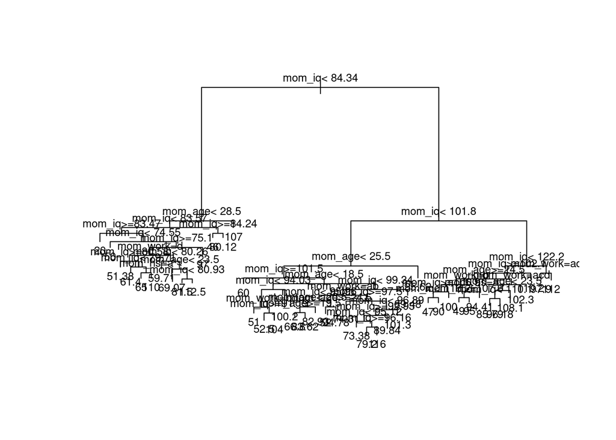

```r
t4 = rpart(kid_score ~ ., data = d, method = "anova",
    control = rpart.control(minsplit = 2, cp = 0.005))
plot(t4, margin = 0.02)
text(t4, cex=.75)
```

- Utilizando validación cruzada (el numero de validaciones viene dado por el parámetro xval), se determina el arbol con un determinado numero de hojas que tenga el mayor R2, o de manera equivalente, el menor error relativo.

```r
t4_printcp = printcp(t4) # lo guardamos en una variable para utilizarlo despues
```

```
##
## Regression tree:
## rpart(formula = kid_score ~ ., data = d, method = "anova", control = rpart.control(minsplit = 2,
##     cp = 0.005))
##
## Variables actually used in tree construction:
## [1] mom_age  mom_hs   mom_iq   mom_work
##
## Root node error: 180386/434 = 415.64
##
## n= 434
##
##           CP nsplit rel error  xerror     xstd
## 1  0.1806158      0   1.00000 1.00127 0.065019
## 2  0.0611036      1   0.81938 0.84406 0.058377
## 3  0.0161612      2   0.75828 0.79300 0.056043
## 4  0.0123630      3   0.74212 0.81819 0.058609
## 5  0.0096481      6   0.70503 0.84877 0.062046
## 6  0.0094469      7   0.69538 0.85162 0.064513
## 7  0.0090591      8   0.68594 0.88128 0.066611
## 8  0.0085517      9   0.67688 0.88187 0.066065
## 9  0.0075110     11   0.65977 0.92354 0.069004
## 10 0.0073281     16   0.61596 0.95197 0.070461
## 11 0.0065568     22   0.57025 0.98724 0.072548
## 12 0.0065249     24   0.55713 1.01506 0.074414
## 13 0.0061137     26   0.54408 1.03150 0.075362
## 14 0.0060254     31   0.51109 1.03255 0.075318
## 15 0.0058459     35   0.48699 1.04422 0.074390
## 16 0.0057384     38   0.46945 1.04552 0.073694
## 17 0.0057263     39   0.46371 1.04573 0.073660
## 18 0.0055520     41   0.45226 1.05287 0.073637
## 19 0.0053275     43   0.44116 1.05683 0.073951
## 20 0.0050000     44   0.43583 1.06747 0.074791
```

- También se puede utilizar plotcp():

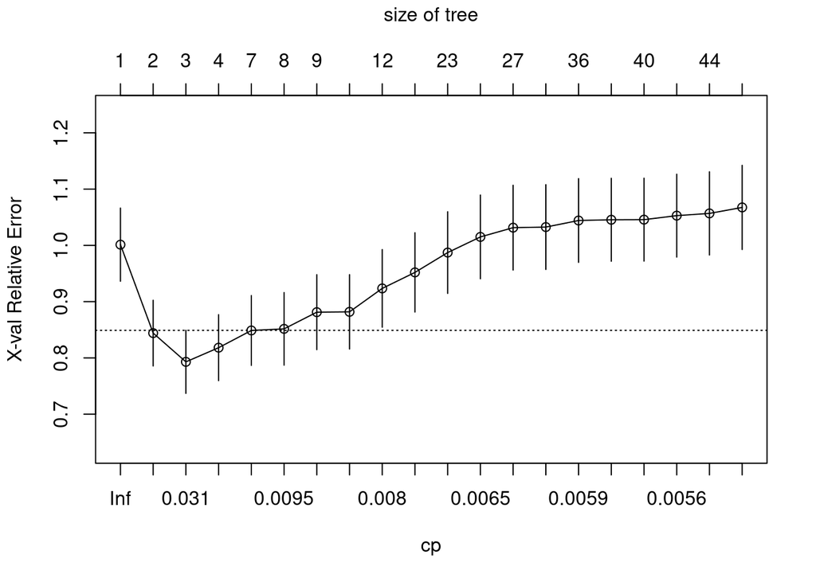

```r
plotcp(t4)
```

- A veces este gráfico tiene un mínimo, por lo que deberíamos seleccionar ese arbol. En caso contrario, elegimos el tamaño donde el error se estabilice.
- Según el gráfico y la tabla anterior, un arbol de 3 hojas parece razonable.

```r
(t4_cp = t4_printcp[3,"CP"])
```

```
## [1] 0.01616121
```

- Ahora podamos el arbol:

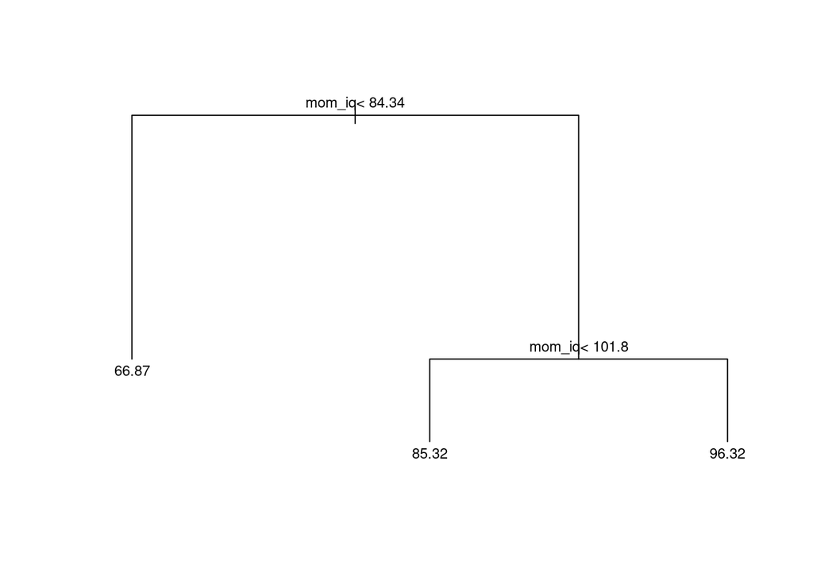

```r
t4_prune = prune(t4, cp = t4_cp)
plot(t4_prune, margin = 0.02)
text(t4_prune, cex=.75)
```

# 5 Prediccion

```r
xp = data.frame(mom_iq = 95, mom_age = 30, mom_hs = "si",
                mom_work = "notrabaja")
predict(t4_prune, newdata = xp)
```

```
##        1
## 85.31937
```

- Mirando el arbol se puede verificar fácilmente la predicción.